# AE 08: Durham climate + factors

Suggested answers

## Getting started

### Packages

We will use the **tidyverse** package in this application exercise.

```r
library(tidyverse)
```

### Data

The data come from https://www.usclimatedata.com/climate/durham/north-carolina/united-states/usnc0192 and are stored as `durham-climate.csv` in the `data` folder.

```r
durham_climate <- read_csv("data/durham-climate.csv")
```

Let’s take a look at the data.

```r
durham_climate
```

```
# A tibble: 12 × 4
   month     avg_high_f avg_low_f precipitation_in
   <chr>          <dbl>     <dbl>            <dbl>
 1 January           49        28             4.45
 2 February          53        29             3.7
 3 March             62        37             4.69
 4 April             71        46             3.43
 5 May               79        56             4.61
 6 June              85        65             4.02
 7 July              89        70             3.94
 8 August            87        68             4.37
 9 September         81        60             4.37
10 October           71        47             3.7
11 November          62        37             3.39
12 December          53        30             3.43
```

## Reorder

What’s wrong with the following plot?

Months are in alphabetical, not chronological, order.

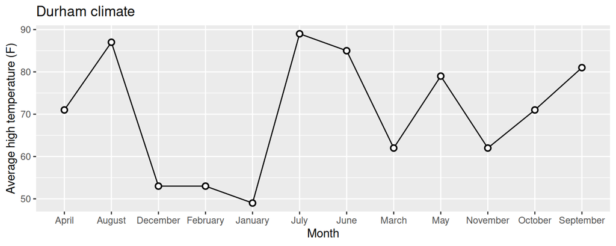

```r
ggplot(
  durham_climate,
  aes(x = month, y = avg_high_f, group = 1)
  ) +
  geom_line() +
  geom_point(
    shape = "circle filled", size = 2,
    color = "black", fill = "white", stroke = 1
  ) +
  labs(
    x = "Month",
    y = "Average high temperature (F)",
    title = "Durham climate"
  )
```

Fix the plot.

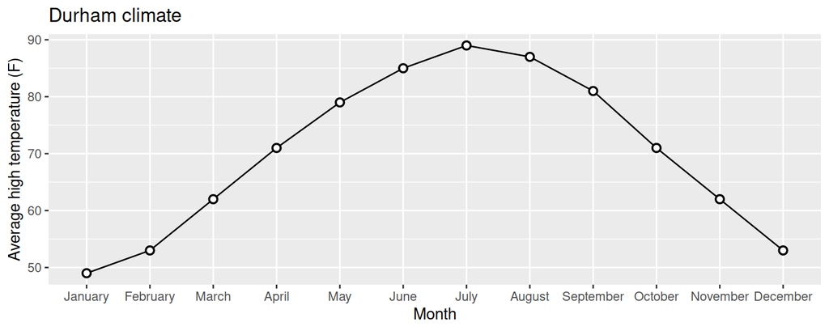

```r
durham_climate |>
  mutate(month = fct_relevel(month, month.name)) |>
  ggplot(
    aes(x = month, y = avg_high_f, group = 1)
  ) +
  geom_line() +
  geom_point(
    shape = "circle filled", size = 2,
    color = "black", fill = "white", stroke = 1
  ) +
  labs(
    x = "Month",
    y = "Average high temperature (F)",
    title = "Durham climate"
  )
```

Perhaps I want the points to be plotted in order of decreasing value (i.e., decreasing avg. high temp). Add code to accomplish this in the chunk below.

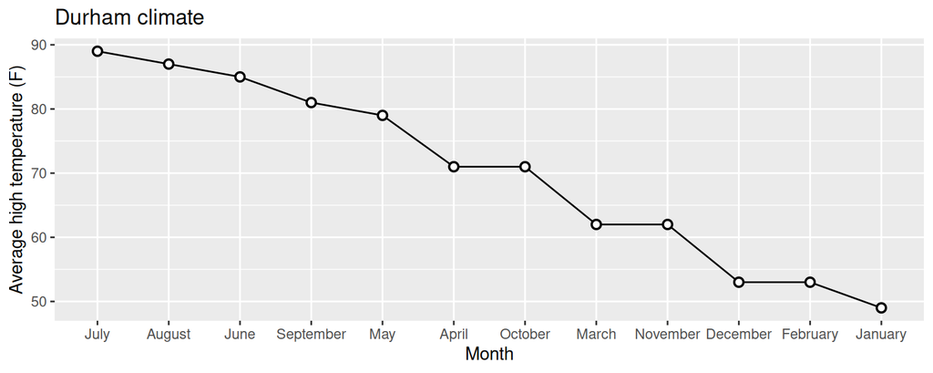

```r
durham_climate <- durham_climate |>
  arrange(desc(avg_high_f)) |>
  mutate(month = factor(month))

durham_climate |>
  mutate(month = fct_reorder(month, avg_high_f, .desc = TRUE)) |>
  ggplot(
    aes(x = month, y = avg_high_f, group = 1)
  ) +
  geom_line() +
  geom_point(
    shape = "circle filled", size = 2,
    color = "black", fill = "white", stroke = 1
  ) +
  labs(
    x = "Month",
    y = "Average high temperature (F)",
    title = "Durham climate"
  )
```

## Recode and reorder

Update the plot above, coloring points based on season. Additionally:

- Make sure the legend is on top of the plot and the seasons appear in the legend in the order they appear in the plot (Winter, Spring, Summer, Fall).
- Use `"circle filled"` as the `shape` for points, set their `size` to 3 points, outline (`stroke`) to 1 point, and fill them in with the following colors:
  - Winter: `lightskyblue1`
  - Spring: `chartreuse3`
  - Summer: `gold2`
  - Fall: `lightsalmon4`

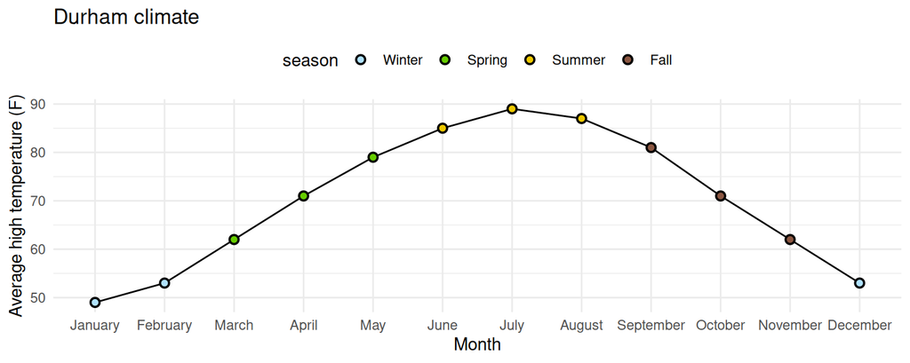

```r
durham_climate <- durham_climate |>
  mutate(month = fct_relevel(month, month.name)) |>
  mutate(season = case_when(
    month %in% c("December", "January", "February") ~ "Winter",
    month %in% c("March", "April", "May") ~ "Spring",
    month %in% c("June", "July", "August") ~ "Summer",
    month %in% c("September", "October", "November") ~ "Fall"),
    season = fct_relevel(season, c("Winter", "Spring", "Summer", "Fall"))
)

ggplot(durham_climate,
  aes(x = month, y = avg_high_f, group = 1)
) +
geom_line() +
geom_point(
  aes(fill = season),
  shape = "circle filled", size = 2, stroke = 1
) +
scale_fill_manual(
  values = c(
    "Winter" = "lightskyblue1",
    "Spring" = "chartreuse3",
    "Summer" = "gold2",
    "Fall" = "lightsalmon4"
  )
) +
labs(
  x = "Month",
  y = "Average high temperature (F)",
  title = "Durham climate"
) +
theme_minimal() +
theme(legend.position = "top")
```

## Pivot

Overlay lines for both high and low temperatures on the same plot. Additionally, use different colors for the two lines – a darker color for high and a lighter color for low temperatures.

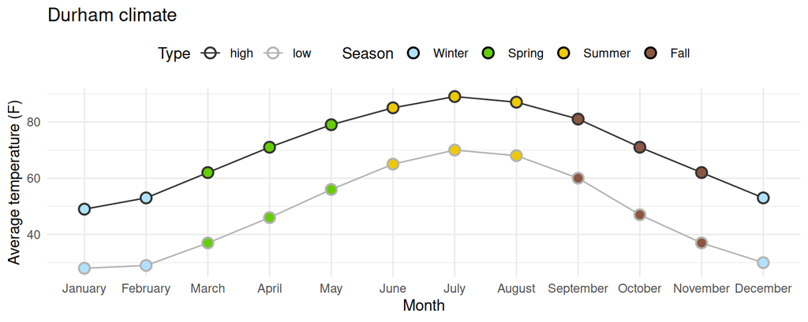

```r
durham_climate_longer <- durham_climate |>
  pivot_longer(
    cols = 2:3,
    names_to = "temp_type",
    ## removes the prefix "avg_" from the pivoted column names
    names_prefix = "avg_",
    values_to = "avg_temp_f"
  ) |>
  ## remove the suffix "_f" from the values in the `temp_type` vector
  mutate(temp_type = str_remove(temp_type, "_f"))

  ggplot(durham_climate_longer, aes(x = month, y = avg_temp_f,
                                    group = temp_type, color = temp_type)) +
  geom_line() +
  geom_point(
    aes(fill = season),
    shape = "circle filled",
    size = 3,
    stroke = 1
  ) +
  scale_fill_manual(
    values = c(
      "Winter" = "lightskyblue1",
      "Spring" = "chartreuse3",
      "Summer" = "gold2",
      "Fall" = "lightsalmon4"
    )
  ) +
  scale_color_manual(
    values = c(
      "high" = "gray20",
      "low" = "gray70"
    )
  ) +
  labs(
    x = "Month",
    y = "Average temperature (F)",
    title = "Durham climate",
    fill = "Season",
    color = "Type"
  ) +
  theme_minimal() +
  theme(legend.position = "top")
```